# ML Lab 4

### Interpret the Coefficients

We aren’t always interested in or able to interpret the model coefficients in a machine learning task. Often predictive accuracy is all we care about.

> Question 6: That said, take a stab at interpreting our model coefficients now.

```r
library(broom)
# Using Broom to interpret our coeffs
tidy(mod_cvs)
```

```
## # A tibble: 2 × 5
##   term        estimate std.error statistic p.value
##   <chr>          <dbl>     <dbl>     <dbl>   <dbl>
## 1 (Intercept)  -6.79     0.116       -58.7       0
## 2 CVS_percent   0.0781   0.00126      62.1       0
```

```r
tidy(mod_bchm)
```

```
## # A tibble: 2 × 5
##   term        estimate std.error statistic p.value
##   <chr>          <dbl>     <dbl>     <dbl>   <dbl>
## 1 (Intercept) -1.99     0.0242       -82.2       0
## 2 BCHM_m       0.00626  0.000105      59.8       0
```

```r
tidy(mod_dbh)
```

```
## # A tibble: 2 × 5
##   term        estimate std.error statistic  p.value
##   <chr>          <dbl>     <dbl>     <dbl>    <dbl>
## 1 (Intercept)  0.407   0.0283         14.4 9.59e-47
## 2 DBH_cm      -0.00378 0.0000779     -48.5 0
```

```r
# Now to exponentiate our coefficients since they're log-transformed
exp(coef(mod_cvs))
```

```
## (Intercept) CVS_percent
## 0.001127365 1.081265308
```

```r
exp(coef(mod_bchm))
```

```
## (Intercept)      BCHM_m
##   0.1369449   1.0062790
```

```r
exp(coef(mod_dbh))
```

```
## (Intercept)      DBH_cm
##    1.501677    0.996225
```

**For each 1 unit increase in CVS_percent, a tree’s odds of death increases multiplicatively by 1.08. For each 1 unit increase in BCHM_m, a tree’s odds of death increases multiplicatively by 1.006. For each 1 unit increase in DBH_cm, a trees odds of death increases multiplicatively by 0.996. In this last case, a 1 unit increase in DBH_cm actually corresponds to a decrease in a trees odds of death, since our multiplier is less than 1.**

> Question 7: Now let’s visualize the results from these models. Plot the fit to the training data of each model.

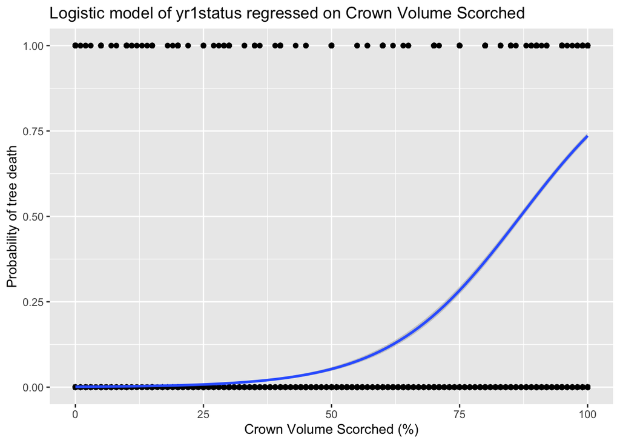

```r
# Visualizing our CVS_percent model
ggplot(trees_training, aes(x = CVS_percent, y = yr1status)) + geom_point() +
  stat_smooth(
    method = "glm",
    se = TRUE,
    method.args = list(family = binomial)
  ) +
labs(title = "Logistic model of yr1status regressed on Crown Volume Scorched", x = "Crown Volume Scorched (%)", y = "Probability of tree death")
```

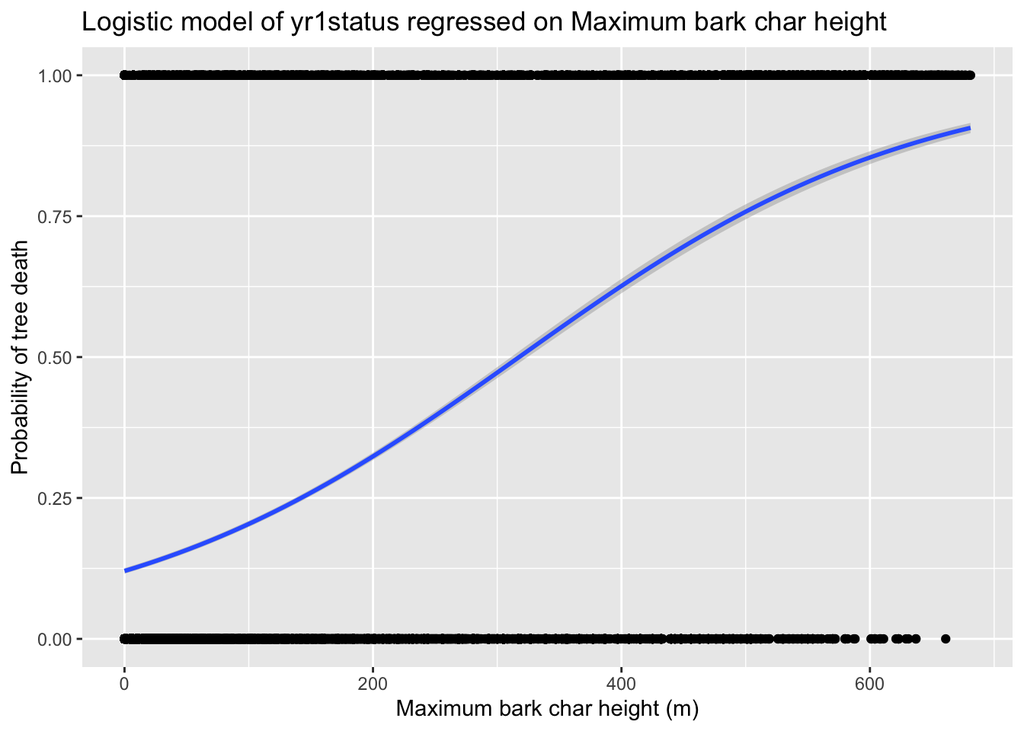

```r
# Then for our BCHM_m model
ggplot(trees_training, aes(x = BCHM_m, y = yr1status)) + geom_point() +
  stat_smooth(
    method = "glm",
    se = TRUE,
    method.args = list(family = binomial)
  ) +
  labs(title = "Logistic model of yr1status regressed on Maximum bark char height", x = "Maximum bark char height (m)", y = "Probability of tree death")
```

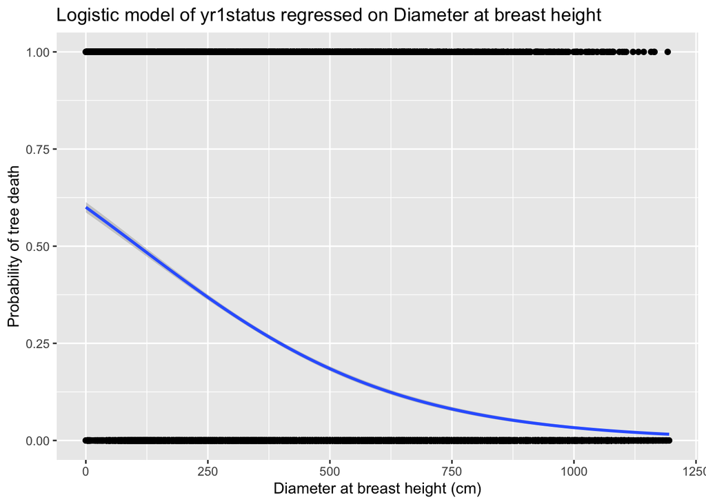

```r
# And for our DBH_cm model
ggplot(trees_training, aes(x = DBH_cm, y = yr1status)) + geom_point() +
  stat_smooth(
    method = "glm",
    se = TRUE,
    method.args = list(family = binomial)
  ) +
    labs(title = "Logistic model of yr1status regressed on Diameter at breast height", x = "Diameter at breast height (cm)", y = "Probability of tree death")
```

### Multiple Logistic Regression

Let’s not limit ourselves to a single-predictor model. More predictors might lead to better model performance.

> Question 8: Use glm() to fit a multiple logistic regression called “logistic_full”, with all three of the predictors included. Which of these are significant in the resulting model?

```r
logistic_full <- glm(data = trees_training, yr1status ~ CVS_percent + DBH_cm + BCHM_m, family = "binomial")

tidy(logistic_full)
```

```
## # A tibble: 4 × 5
##   term        estimate std.error statistic   p.value
##   <chr>          <dbl>     <dbl>     <dbl>     <dbl>
## 1 (Intercept) -5.25     0.118        -44.5 0
## 2 CVS_percent  0.0638   0.00123       51.9 0
## 3 DBH_cm      -0.00363  0.000119     -30.6 3.60e-205
## 4 BCHM_m       0.00460  0.000162      28.5 3.13e-178
```

**Each of these variables are significant in the resulting model, since the p-values for each of them are essentially 0.**

### Estimate Model Accuracy

Now we want to estimate our model’s generalizability using resampling.

> Question 9: Use cross validation to assess model accuracy. Use caret::train() to fit four 10-fold cross-validated models (cv_model1, cv_model2, cv_model3, cv_model4) that correspond to each of the four models we’ve fit so far: three simple logistic regression models corresponding to each of the three key predictors (CVS_percent, DBH_cm, BCHM_m) and a multiple logistic regression model that combines all three predictors.

```r
trees_training$yr1status <- as.factor(trees_training$yr1status)
levels(trees_training$yr1status) <- make.names(levels(trees_training$yr1status))


train_control <- trainControl(method = "cv", number = 10, classProbs = TRUE)

# First model based on CVS_percent
cv_model1 <- train(as.factor(yr1status) ~ CVS_percent, data = trees_training, method = "glm", family = 'binomial', trControl = train_control)

# Second model based on DBH_cm
cv_model2 <- train(as.factor(yr1status) ~ DBH_cm, data = trees_training, method = "glm", family = 'binomial', trControl = train_control)

# Third model based on BCHM_m
cv_model3 <- train(as.factor(yr1status) ~ BCHM_m, data = trees_training, method = "glm", family = 'binomial', trControl = train_control)

# Fourth model based on all variables
cv_model4 <- train(as.factor(yr1status) ~ CVS_percent + DBH_cm + BCHM_m, data = trees_training, method = "glm", family = 'binomial', trControl = train_control)
```

> Question 10: Use caret::resamples() to extract then compare the classification accuracy for each model. (Hint: resamples() wont give you what you need unless you convert the outcome variable to factor form). Which model has the highest accuracy?

```r
# Storing each model to a list
results <- resamples(list(Model1 = cv_model1, Model2 = cv_model2, Model3 = cv_model3, Model4 = cv_model4))

# Looking at the results
summary(results)
```

```
##
## Call:
## summary.resamples(object = results)
##
## Models: Model1, Model2, Model3, Model4
## Number of resamples: 10
##
## Accuracy
##             Min.   1st Qu.    Median      Mean   3rd Qu.      Max. NA's
## Model1 0.8930269 0.8979208 0.8992083 0.8989149 0.9015550 0.9025357    0
## Model2 0.7461386 0.7496783 0.7526245 0.7535452 0.7546535 0.7631683    0
## Model3 0.7592079 0.7670297 0.7694591 0.7700238 0.7724078 0.7805071    0
## Model4 0.8961965 0.9004258 0.9035451 0.9042628 0.9048232 0.9219493    0
##
## Kappa
##             Min.   1st Qu.    Median      Mean   3rd Qu.      Max. NA's
## Model1 0.7536190 0.7643070 0.7678182 0.7671607 0.7736514 0.7753421    0
## Model2 0.2064245 0.2197520 0.2311940 0.2343148 0.2393445 0.2725019    0
## Model3 0.2993742 0.3271987 0.3372984 0.3361756 0.3418179 0.3701256    0
## Model4 0.7527185 0.7638486 0.7699581 0.7722260 0.7726730 0.8144458    0
```

**It looks like model 4 has the highest overall accuracy**

> Let’s move forward with this single most accurate model.

> Question 11: Compute the confusion matrix and overall fraction of correct predictions by the model.

```r
pred_class <- predict(cv_model4, trees_training)

confusionMatrix(data = pred_class,
                reference = factor(trees_training$yr1status))
```

```
## Confusion Matrix and Statistics
##
##           Reference
## Prediction    X0    X1
##         X0 16466   804
##         X1  1617  6359
##
##                Accuracy : 0.9041
##                  95% CI : (0.9004, 0.9077)
##     No Information Rate : 0.7163
##     P-Value [Acc > NIR] : < 2.2e-16
##
##                   Kappa : 0.7719
##
##  Mcnemar's Test P-Value : < 2.2e-16
##
##             Sensitivity : 0.9106
##             Specificity : 0.8878
##          Pos Pred Value : 0.9534
##          Neg Pred Value : 0.7973
##              Prevalence : 0.7163
##          Detection Rate : 0.6522
##    Detection Prevalence : 0.6841
##       Balanced Accuracy : 0.8992
##
##        'Positive' Class : X0
##
```

**The overall fraction of correct predictions by the model is ~90/100**

> Question 12: Explain what the confusion matrix is telling you about the types of mistakes made by logistic regression.

**The confusion matrix shows us that the model is more likely to predict false positives than false negatives. That is, it is more likely to predict that a tree is dead when it is actually alive than predicting a tree is alive when it is actually dead**

> Question 13: What is the overall accuracy of the model? How is this calculated?

> **The overall accuracy of this model is ~90%. It is calculated by dividing the sum of observed true positives and true negatives with the sum of observed true positives, true negatives, false positives, and false negatives.**

### Test Final Model

Alright, now we’ll take our most accurate model and make predictions on some unseen data (the test data).

> Question 14: Now that we have identified our best model, evaluate it by running a prediction on the test data, trees_test.

```r
trees_testing$yr1status <- as.factor(trees_testing$yr1status)
levels(trees_testing$yr1status) <- make.names(levels(trees_testing$yr1status), unique = TRUE)
final_model <- train(as.factor(yr1status) ~ CVS_percent + DBH_cm + BCHM_m, data = trees_training,family = 'binomial', method = 'glm')

pred_final <- predict(final_model, trees_testing)
```

> Question 15: How does the accuracy of this final model on the test data compare to its cross validation accuracy?

```r
confusionMatrix(data = pred_final, reference = factor(trees_testing$yr1status))
```

```
## Confusion Matrix and Statistics
##
##           Reference
## Prediction   X0   X1
##         X0 7056  390
##         X1  694 2680
##
##                Accuracy : 0.8998
##                  95% CI : (0.894, 0.9054)
##     No Information Rate : 0.7163
##     P-Value [Acc > NIR] : < 2.2e-16
##
##                   Kappa : 0.7607
##
##  Mcnemar's Test P-Value : < 2.2e-16
##
##             Sensitivity : 0.9105
##             Specificity : 0.8730
##          Pos Pred Value : 0.9476
##          Neg Pred Value : 0.7943
##              Prevalence : 0.7163
##          Detection Rate : 0.6521
##    Detection Prevalence : 0.6882
##       Balanced Accuracy : 0.8917
##
##        'Positive' Class : X0
##
```

> Do you find this to be surprising? Why or why not?

> **The final model had an accuracy of ~90%, which is almost identical to its performance on the training data. This is not surprising, since we stratified on our outcome variable to address any class imbalances, we should achieve a similar score on our out of sample data.**